# 487_HW2

2024-10-08

```r
knitr::opts_chunk$set(echo = TRUE) # sets default behavior to include code in the HTML file, please keep

rm(list = ls()) # clears the environment of any existing objects

suppressPackageStartupMessages({ # reduces annoying printing
  library(janitor) # has helpful cleaning functions
  library(knitr) # knitting functions (transforming RMarkdown file to HTML)
  library(lubridate) # date parsing functions
  library(scales) # library for formatting ggplot axes
  library(tidyverse) # workhorse dplyr package
  library(ggplot2) # load ggplot for aesthetics
  library(tidyverse)
  library(broom)
})

options(dplyr.summarise.inform = FALSE) # turns off an annoying dplyr behavior

set.seed(487) # setting the seed makes random operations reproducible
```

#### Empirical Section 1-3: set directory, load data, and view table

```r
OJ <- read.csv("Orange Juice.csv" , na.strings = "?")
head(OJ)
```

```
##   store     brand week  logmove feat price     AGE60      EDUC    ETHNIC
## 1     2 tropicana   40 9.018695    0  3.87 0.2328647 0.2489349 0.1142799
## 2     2 tropicana   46 8.723231    0  3.87 0.2328647 0.2489349 0.1142799
## 3     2 tropicana   47 8.253228    0  3.87 0.2328647 0.2489349 0.1142799
## 4     2 tropicana   48 8.987197    0  3.87 0.2328647 0.2489349 0.1142799
## 5     2 tropicana   50 9.093357    0  3.87 0.2328647 0.2489349 0.1142799
## 6     2 tropicana   51 8.877382    0  3.87 0.2328647 0.2489349 0.1142799
##     INCOME   HHLARGE   WORKWOM   HVAL150 SSTRDIST  SSTRVOL CPDIST5   CPWVOL5
## 1 10.55321 0.1039534 0.3035853 0.4638871 2.110122 1.142857 1.92728 0.3769266
## 2 10.55321 0.1039534 0.3035853 0.4638871 2.110122 1.142857 1.92728 0.3769266
## 3 10.55321 0.1039534 0.3035853 0.4638871 2.110122 1.142857 1.92728 0.3769266
## 4 10.55321 0.1039534 0.3035853 0.4638871 2.110122 1.142857 1.92728 0.3769266
## 5 10.55321 0.1039534 0.3035853 0.4638871 2.110122 1.142857 1.92728 0.3769266
## 6 10.55321 0.1039534 0.3035853 0.4638871 2.110122 1.142857 1.92728 0.3769266
```

#### Empirical Section 4: price visulaization using box plots

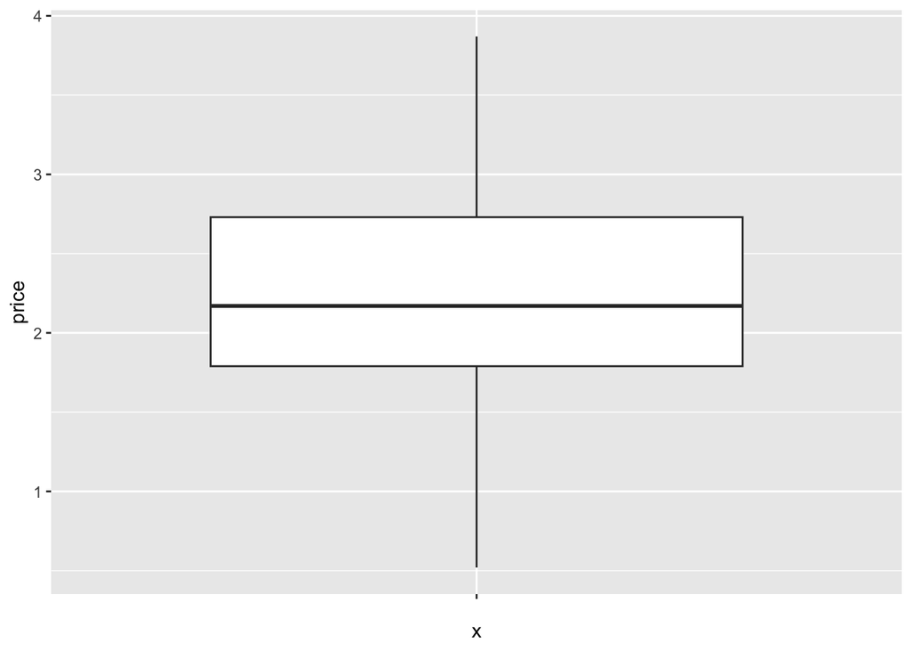

```r
# Access variable from the OJ data frame
price <- OJ$price
log_price <- log(OJ$price)
brand <-OJ$brand

# Box plot produced by price
ggplot(data = OJ, aes(x = "", y = price)) + geom_boxplot()
```

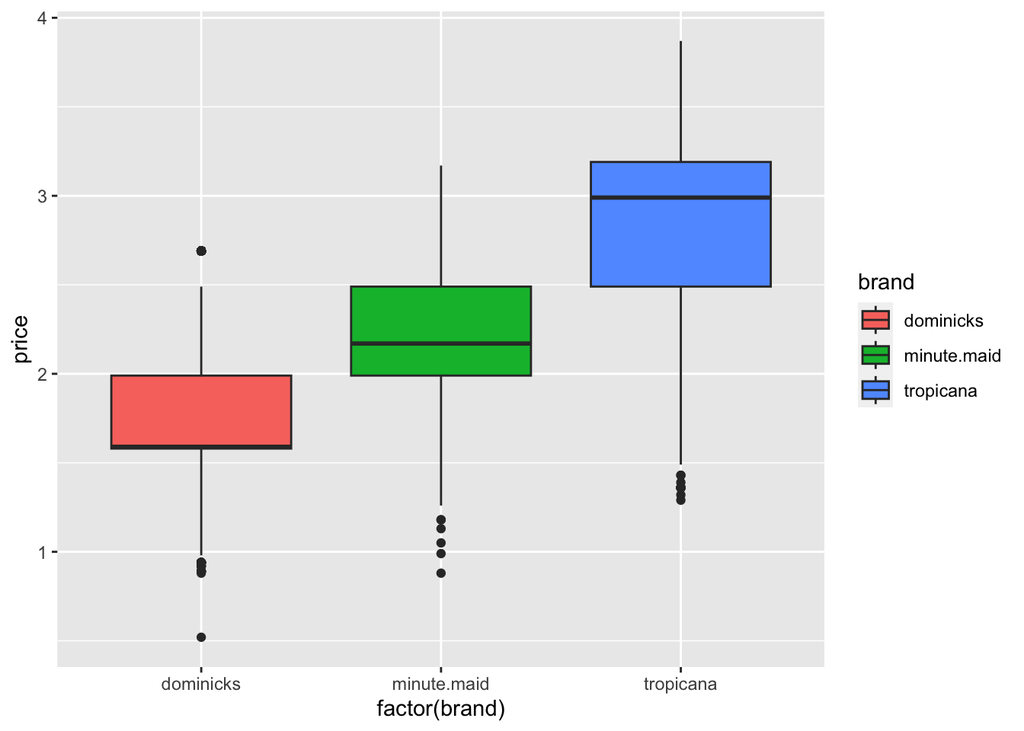

```r
# Box plot on price on brands (qualitative factor)
ggplot(OJ, aes(factor(brand), price)) + geom_boxplot(aes(fill = brand))
```

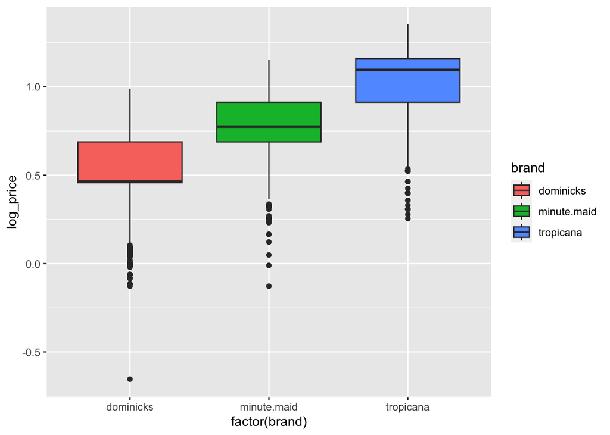

```r
# Box plot on log_price on brands (qualitative factor)
ggplot(OJ, aes(factor(brand), log_price)) + geom_boxplot(aes(fill = brand))
```

What do these graphs tell you about the variation in price? Why do the log plots look different? Do you find them more/less informative?

The box and whisker length both tell us about the variation of price, where tropicana has more variation than minute maid and dominicks;but with log_price, we see that it is the dominicks that is the more variation. Log_price should provide more information in regard to the actual variation, becuase it reflects the proportionality from our data.

#### Empirical Section 5: scatter plots and regressions

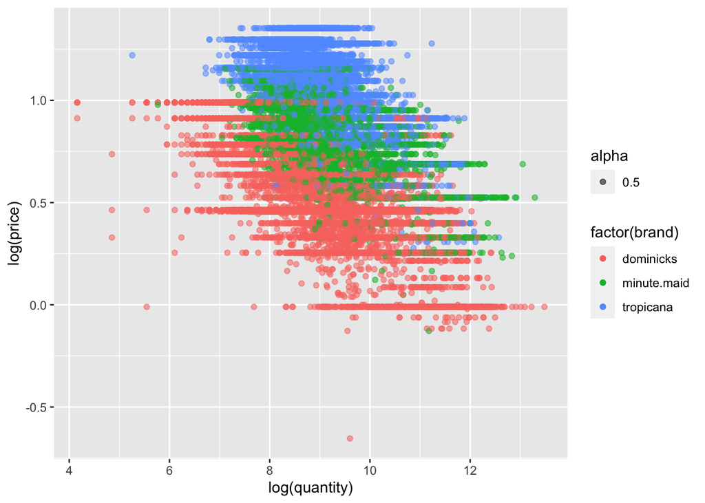

```r
log_quant<- OJ$logmove
ggplot(OJ, aes(log_quant, log_price)) +geom_point(aes(color = factor(brand), alpha=.5)) + labs(y = 'log(price)',
       x = 'log(quantity)')
```

```r
# Regression of log(quantity) on log(price)
basic_reg <- lm(
  formula = logmove ~ log(price),
  data = OJ
)
tidy(basic_reg) %>% # dplyr piping
  kable()
```

| term | estimate | std.error | statistic | p.value |
| --- | --- | --- | --- | --- |
| (Intercept) | 10.423422 | 0.0153502 | 679.04294 | 0 |
| log(price) | -1.601307 | 0.0183583 | -87.22507 | 0 |

```r
# Regression of log(quantity) on log(price) with brand intercepts
brand_reg <- lm(
  formula = logmove ~ log(price) + brand,
  data = OJ
)
tidy(brand_reg) %>%
  kable()
```

| term | estimate | std.error | statistic | p.value |
| --- | --- | --- | --- | --- |
| (Intercept) | 10.8288216 | 0.0145345 | 745.04109 | 0 |
| log(price) | -3.1386914 | 0.0229289 | -136.88809 | 0 |
| brandminute.maid | 0.8701747 | 0.0129260 | 67.31994 | 0 |
| brandtropicana | 1.5299428 | 0.0163093 | 93.80820 | 0 |

```r
# Regression of log(quantity) on log(price) with Dominick's removed as base intercept
no_int_brand_reg <- lm(
  formula = logmove ~ log(price) + brand - 1,
  data = OJ
)
tidy(no_int_brand_reg) %>%
  kable()
```

| term | estimate | std.error | statistic | p.value |
| --- | --- | --- | --- | --- |
| log(price) | -3.138691 | 0.0229289 | -136.8881 | 0 |
| branddominicks | 10.828822 | 0.0145345 | 745.0411 | 0 |
| brandminute.maid | 11.698996 | 0.0198479 | 589.4327 | 0 |
| brandtropicana | 12.358764 | 0.0250599 | 493.1686 | 0 |

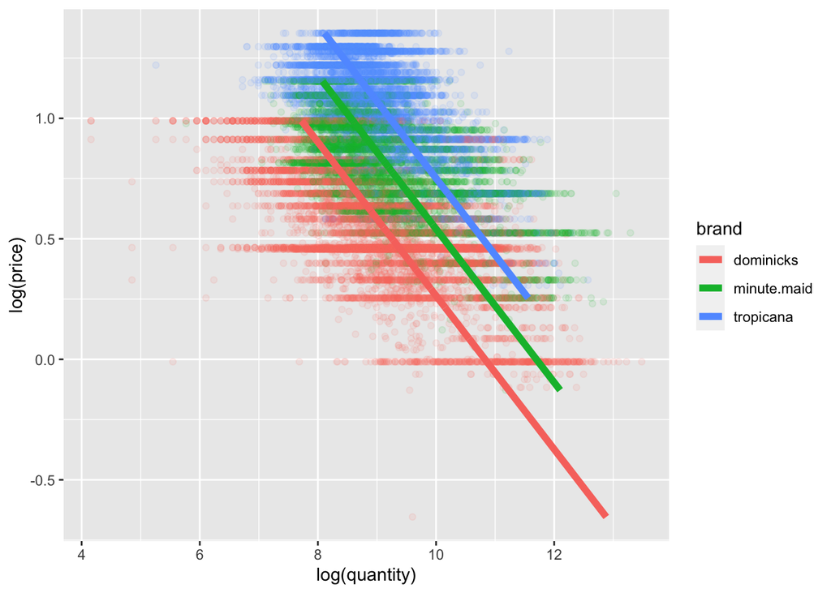

```r
# Regression of log(quantity) on log(price) with brand intercepts plotted on top of scatter plot
OJ %>% mutate(fitted_y = predict(brand_reg, newdata=.)) %>%
    ggplot(data = .) + geom_point(aes(x = logmove, y = log(price), color = brand), alpha=.1) +
    geom_line(aes(x = fitted_y, y = log(price), color = brand), linewidth = 2) +
    labs(y = 'log(price)', x = 'log(quantity)')
```

#### Empirical Section 6: demand elasticities ((dq/dp)*(P/Q))

```r
# Part A: Regression of log(quantity) on log(price)
modelA <- lm(log_quant ~ log_price)
cat('MSE of model A:', mean(modelA$residuals^2), '\n')
```

```
## MSE of model A: 0.8228178
```

```r
cat('Elasticity of model A:', coefficients(modelA)["log_price"], '\n')
```

```
## Elasticity of model A: -1.601307
```

```r
# Part B:Regression of log(quantity) on log(price) with brand intercepts
modelB <- lm(log_quant ~ log_price + OJ$brand)
cat('MSE of model B:', mean(modelB$residuals^2), '\n')
```

```
## MSE of model B: 0.6295934
```

```r
cat('Elasticity of model B:', coefficients(modelB)["log_price"], '\n')
```

```
## Elasticity of model B: -3.138691
```

```r
# Part C:Regression of log(quantity) on log(price) interacted with brand intercepts
modelC <- lm(log_quant ~ log_price:factor(OJ$brand))
cat('MSE of model C:', mean(modelC$residuals^2), '\n')
```

```
## MSE of model C: 0.6414356
```

```r
cat('Elasticity of model C:', coefficients(modelC)["(Intercept)"], '\n')
```

[output not shown]

```r
run_brand_regression <- function(brand_name){
  data_reg <- OJ %>%
    filter(brand == brand_name)
  lm(logmove ~ log(price), data = data_reg) %>%
    tidy() %>%
    kable()
}
run_brand_regression('dominicks')
```

| term | estimate | std.error | statistic | p.value |
| --- | --- | --- | --- | --- |
| (Intercept) | 10.95468 | 0.0242429 | 451.87114 | 0 |
| log(price) | -3.37753 | 0.0423807 | -79.69497 | 0 |

```r
run_brand_regression('minute.maid')
```

| term | estimate | std.error | statistic | p.value |
| --- | --- | --- | --- | --- |
| (Intercept) | 11.842935 | 0.0355164 | 333.44993 | 0 |
| log(price) | -3.320735 | 0.0437818 | -75.84738 | 0 |

```r
run_brand_regression('tropicana')
```

| term | estimate | std.error | statistic | p.value |
| --- | --- | --- | --- | --- |
| (Intercept) | 11.917071 | 0.0337036 | 353.58450 | 0 |
| log(price) | -2.711769 | 0.0319596 | -84.84994 | 0 |

How well does the model fit? What is the elasticity, does it make sense? ModelA fits pretty bad relative to ModelC, based on our MSE value. It makes sense that MOdel B fits better than ModelA as it captures the dyanmic of the orange juice market with different brands exist within the market

How do the results change? How should we interpret these coefficients? ModelB improves upon ModelA, and we see that the elasticity has increased (|-3.13|> |-1.60|). The total effect of adding brand as intercept terms has increased the demand elasticity of the demand for orange juice

What is the insights we get from this regression? What is the elasticity for each firm? Do the elasticities make sense? The higher the priced brand (dominics -> minute.maid -> tropicana), the less elastic the firm is. It make sense, because orange juice brands are substitutes.

#### Problem 7: advertisement effect (var_name = feat) on log_quantity

```r
# Part A: Average Rate of Each Brand Featuring and Price
OJ %>%
  group_by(brand) %>%
  summarise(avg_price = mean(price), featured_rate = mean(feat))
```

```
## # A tibble: 3 × 3
##   brand       avg_price featured_rate
##   <chr>           <dbl>         <dbl>
## 1 dominicks        1.74         0.257
## 2 minute.maid      2.24         0.289
## 3 tropicana        2.87         0.166
```

```r
# Part B: Additive Effect of Feat Variable
modelB <- lm(log_quant ~ log_price + OJ$feat + factor(OJ$brand))
tidy(modelB) %>%
  kable()
```

[output not shown]

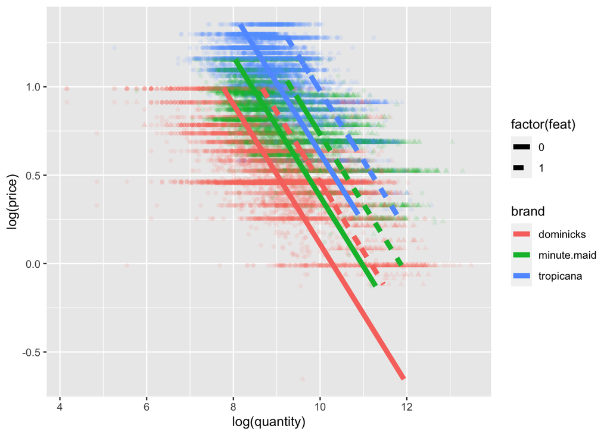

```r
OJ %>% mutate(fitted_y = predict(modelB, newdata=.)) %>%
    ggplot(data = .) + geom_point(aes(x = logmove, y = log(price), color = brand, shape = factor(feat)), alpha=.1) +
    geom_line(aes(x = fitted_y, y = log(price), color = brand, linetype = factor(feat)), linewidth = 2) +
    labs(y = 'log(price)', x = 'log(quantity)')
```

```r
# Part C: A model that should impact sales and price sensitivity
modelC <- lm(log_quant ~ log(price) + feat + log(price):feat + brand + brand:log(price), data = OJ)
tidy(modelC) %>%
  kable()
```

| term | estimate | std.error | statistic | p.value |
| --- | --- | --- | --- | --- |
| (Intercept) | 10.2678445 | 0.0218443 | 470.047031 | 0.0000000 |
| log(price) | -2.6018680 | 0.0359073 | -72.460623 | 0.0000000 |
| feat | 1.4000006 | 0.0280893 | 49.840976 | 0.0000000 |
| brandminute.maid | 0.6059097 | 0.0374164 | 16.193680 | 0.0000000 |
| brandtropicana | 0.8424085 | 0.0428319 | 19.667795 | 0.0000000 |
| log(price):feat | -0.7521358 | 0.0390602 | -19.255796 | 0.0000000 |
| log(price):brandminute.maid | 0.1864438 | 0.0514809 | 3.621614 | 0.0002933 |
| log(price):brandtropicana | 0.5481054 | 0.0496887 | 11.030781 | 0.0000000 |

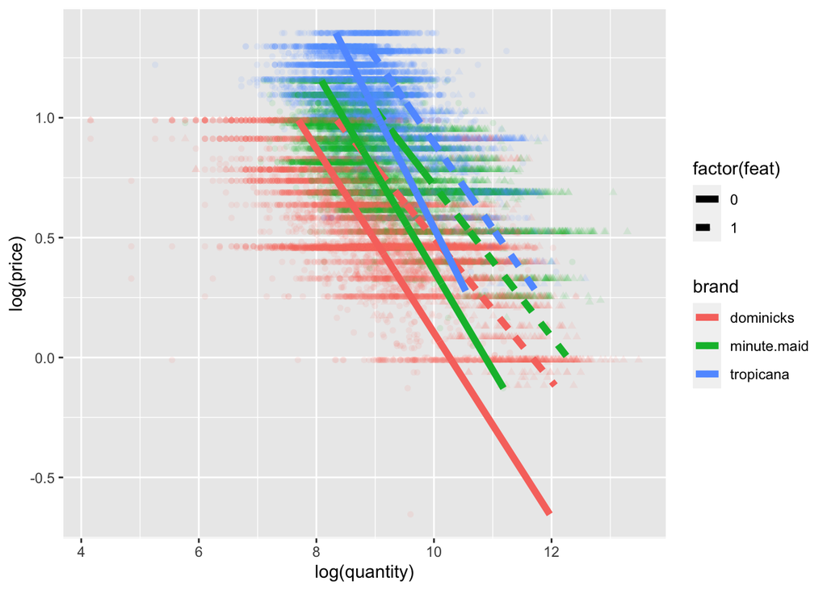

```r
OJ %>% mutate(fitted_y = predict(modelC, newdata=.)) %>%
    ggplot(data = .) + geom_point(aes(x = logmove, y = log(price), color = brand, shape = factor(feat)), alpha=.1) +
    geom_line(aes(x = fitted_y, y = log(price), color = brand, linetype = factor(feat)), linewidth = 2) +
    labs(y = 'log(price)', x = 'log(quantity)')
```

```r
# Part D: A model that should have different impact of being featured and on price sensitivity
modelD <- lm(log_quant ~ log_price*feat*brand, data = OJ)
tidy(modelD) %>%
  kable()
```

| term | estimate | std.error | statistic | p.value |
| --- | --- | --- | --- | --- |
| (Intercept) | 10.4065758 | 0.0233505 | 445.667820 | 0.0000000 |
| log_price | -2.7741544 | 0.0388292 | -71.445007 | 0.0000000 |
| feat | 1.0944067 | 0.0381042 | 28.721434 | 0.0000000 |
| brandminute.maid | 0.0472032 | 0.0466288 | 1.012317 | 0.3113949 |
| brandtropicana | 0.7079409 | 0.0507966 | 13.936768 | 0.0000000 |
| log_price:feat | -0.4705533 | 0.0740913 | -6.350989 | 0.0000000 |
| log_price:brandminute.maid | 0.7829321 | 0.0614041 | 12.750480 | 0.0000000 |
| log_price:brandtropicana | 0.7357930 | 0.0568360 | 12.945894 | 0.0000000 |
| feat:brandminute.maid | 1.1729436 | 0.0819558 | 14.311908 | 0.0000000 |
| feat:brandtropicana | 0.7852524 | 0.0987480 | 7.952084 | 0.0000000 |
| log_price:feat:brandminute.maid | -1.1092238 | 0.1222461 | -9.073692 | 0.0000000 |
| log_price:feat:brandtropicana | -0.9861409 | 0.1241086 | -7.945792 | 0.0000000 |

```r
# Part E:A model that should impact sales and price sensitivity + demographics
modelE <- lm(log_quant ~ log(price) + feat + log(price):feat + brand + brand:log(price) + AGE60 + EDUC + ETHNIC + HHLARGE + WORKWOM + HVAL150 + SSTRDIST + SSTRVOL + CPDIST5 + CPWVOL5 , data = OJ)
tidy(modelE) %>%
  kable()
```

| term | estimate | std.error | statistic | p.value |
| --- | --- | --- | --- | --- |
| (Intercept) | 10.3419570 | 0.0935255 | 110.579026 | 0.0000000 |
| log(price) | -2.6761310 | 0.0341361 | -78.395887 | 0.0000000 |
| feat | 1.3669590 | 0.0266348 | 51.322311 | 0.0000000 |
| brandminute.maid | 0.6364702 | 0.0354920 | 17.932803 | 0.0000000 |
| brandtropicana | 0.8852087 | 0.0406199 | 21.792464 | 0.0000000 |
| AGE60 | 1.8305310 | 0.1262035 | 14.504598 | 0.0000000 |
| EDUC | 0.5323557 | 0.0898318 | 5.926136 | 0.0000000 |
| ETHNIC | 0.8234333 | 0.0307630 | 26.767003 | 0.0000000 |
| HHLARGE | -1.8773834 | 0.2025810 | -9.267321 | 0.0000000 |
| WORKWOM | -0.5903255 | 0.1471625 | -4.011385 | 0.0000605 |
| HVAL150 | 0.3357246 | 0.0421259 | 7.969549 | 0.0000000 |
| SSTRDIST | -0.0184762 | 0.0014764 | -12.514725 | 0.0000000 |
| SSTRVOL | -0.0437932 | 0.0097953 | -4.470832 | 0.0000078 |
| CPDIST5 | 0.0447380 | 0.0059521 | 7.516400 | 0.0000000 |
| CPWVOL5 | -0.5214208 | 0.0258531 | -20.168603 | 0.0000000 |
| log(price):feat | -0.7217103 | 0.0370101 | -19.500377 | 0.0000000 |
| log(price):brandminute.maid | 0.1703573 | 0.0487854 | 3.491973 | 0.0004802 |
| log(price):brandtropicana | 0.5392994 | 0.0470670 | 11.458123 | 0.0000000 |